# Report for ancestral area estimation using the FIG model

Author

Friederike Wölke

Published

June 24, 2026

# FIG model

> The FIG model extends the GeoSSE model by allowing regional features to shape biogeographic rates (Landis et al. 2022; Swiston and Landis 2023). The purpose of FIG is to allow biologists to test new hypotheses that involve the timing and location of phylogenetic, biogeographic, and paleogeographic events. *Source*: https://revbayes.github.io/tutorials/fig_intro/

## TimeFIG

> Dating with TimeFIG jointly estimates phylogenetic divergence times, molecular substitution rates, biogeographic rates, and ancestral species ranges. The tutorial provides a conceptual background on challenges related to dating molecular phylogenies, alternative techniques for dating, and a framework to assess the sensitivity of divergence time estimates to methodological assumptions. *Source*: https://revbayes.github.io/tutorials/timefig_dating/#molecular-phylogenetics

## Requirements:

https://revbayes.github.io/tutorials/docker/

- **Docker (+ DockerHub account)** to install **PhyloDocker** image from https://hub.docker.com/r/sswiston/phylo_docker
  - open Docker Desktop
  - download image from [url](https://hub.docker.com/r/sswiston/phylo_docker): open **Git Bash** and run:

    ```
    docker pull sswiston/phylo_docker:rev_update
    ```

  - open the image: *(from powershell works)*

    ```
    docker run --name RevBayes_docker2 `
      -v "${PWD}:/FIG_model" `
      -it sswiston/phylo_docker:rev_update /bin/sh
    ```

  - start the container: `docker start RevBayes_docker2`
  - Open the container: `docker exec -it RevBayes_docker2 /bin/sh`
  - `cd` to `FIG_model`
  - start RevBayes with: `rb`
  - `loadPlugin("TensorPhylo")`
  - run RevBayes scripts like this: `rb scripts/fig-model/1_molecular_phylogenetics/01_divtime_uncalibrated.Rev`

### A) Biogeographic dating with node dating (fixed tree)

```bash
# activate docker container
docker start RevBayes_docker2
docker exec -it RevBayes_docker2 /bin/sh
cd FIG_model
```

```bash
rb scripts/fig-model/2_timefig/01_timefig_model.Rev
```

```bash
# open rev bayes
rb
```

```bash
loadPlugin("TensorPhylo")
```

```bash
# filesystem
analysis      = "simple_timefig"
dat_fp        = "./data/output/paleo/"
phy_fn        = "./data/output/clock_model_plstm/plstm_global.phangorn-mcc.tre"
bg_fn         = "./data/input/Uapaca_range_plastome.nex"
label_fn      = "./data/output/ancestral-areas-DEC/DEC_nuc.state_labels.txt"
geo_fp        = "./data/output/paleo/"
feature_fn    = geo_fp + "feature_summary.csv"
times_fn      = geo_fp + "age_summary.csv"
out_fn        = "./data/output/timefig/" + analysis
```

```bash
# MCMC variables
num_proc  = 6
num_gen   = 500          # set num_gen = 5000 for full analysis
print_gen = 1
moves     = VectorMoves()
monitors  = VectorMonitors()
```

```bash
phy <- readTrees(phy_fn)[1]
taxa         = phy.taxa()
num_taxa     = taxa.size()
num_branches = 2 * num_taxa - 2



dat_01 = readDiscreteCharacterData(bg_fn)
num_regions    = dat_01.nchar()
max_range_size = 2
num_ranges     = 0
for (k in 1:max_range_size) {
    num_ranges += choose(num_regions, k)
}
dat_nn         = formatDiscreteCharacterData(dat_01, format="GeoSSE", numStates=num_ranges)
desc           = dat_nn.getStateDescriptions()

write("index,range\n", filename=label_fn)
for (i in 1:desc.size()) {
    write((i-1) + "," + desc[i] + "\n", filename=label_fn, append=true)
}
```

```bash
times_table = readDataDelimitedFile(times_fn, delimiter=",", header=true)
num_times <- times_table.size()
for (i in 1:(num_times-1)) { times[i] <- times_table[i][2] }
```

```bash
geo_features <- readRegionalFeatures(feature_fn, delimiter=",")
geo_features.normalize("within")
geo_features.normalize("between")

# get feature-sets for each measurement-type, process-type, and timeslice
for (i in 1:num_times) {

    print("time = " + i)

    feature_CW[i] <- geo_features.get("within","categorical",i)
    feature_QW[i] <- geo_features.get("within","quantitative",i)
    feature_CB[i] <- geo_features.get("between","categorical",i)
    feature_QB[i] <- geo_features.get("between","quantitative",i)

    for (j in 1:feature_CW[i].size()) {
        layer_CW[i][j] <- feature_CW[i][j].get()
    }
    for (j in 1:feature_QW[i].size()) {
        layer_QW[i][j] <- feature_QW[i][j].get()
    }
    for (j in 1:feature_CB[i].size()) {
        layer_CB[i][j] <- feature_CB[i][j].get()
    }
    for (j in 1:feature_QB[i].size()) {
        layer_QB[i][j] <- feature_QB[i][j].get()
    }
}
```

```bash
# set up priors for feature effects
rj_null_value <- 0.0          # fixed "off-value" for RJMCMC
rj_prob       <- 0.5          # prob. of RJMCMC taking "off-value"

# prior of "on-value" for RJMCMC
bound <- 2
rj_base_sym_dist = dnUniform(-bound, bound)
rj_base_neg_dist = dnUniform(-bound, 0)     # negative only (e.g. distance on dispersal)
rj_base_pos_dist = dnUniform(0, bound)      # positive only (e.g. distance on betw.-reg. speciation)
rj_sym_dist = dnRJMixture(rj_null_value, rj_base_sym_dist, p=rj_prob)
rj_neg_dist = dnRJMixture(rj_null_value, rj_base_neg_dist, p=rj_prob)
rj_pos_dist = dnRJMixture(rj_null_value, rj_base_pos_dist, p=rj_prob)

# categorical feature effects
for (i in 1:feature_CW[1].size()) sigma_w[i] ~ rj_sym_dist
for (i in 1:feature_CW[1].size()) sigma_e[i] ~ rj_sym_dist
for (i in 1:feature_CB[1].size()) sigma_d[i] ~ rj_sym_dist
for (i in 1:feature_CB[1].size()) sigma_b[i] ~ rj_sym_dist

# quantitative feature effects
for (i in 1:feature_QW[1].size()) phi_w[i] ~ rj_sym_dist
for (i in 1:feature_QW[1].size()) phi_e[i] ~ rj_sym_dist
for (i in 1:feature_QB[1].size()) phi_d[i] ~ rj_sym_dist
for (i in 1:feature_QB[1].size()) phi_b[i] ~ rj_sym_dist

# force signed relationships between region features and rates
# (overrides existing distribution assignments)
phi_b[1]   ~ rj_pos_dist   # Distance (km) results in faster speciation
phi_b[2]   ~ rj_pos_dist   # Log-distance (km) results in faster speciation
sigma_b[1] ~ rj_pos_dist   # LDD (1) results in faster speciation
sigma_w[1] ~ rj_pos_dist   # High Islands (1) drives faster speciation
phi_d[1]   ~ rj_neg_dist   # Distance (km) results in slower dispersal
phi_d[2]   ~ rj_neg_dist   # Log-distance (km) results in slower dispersal
sigma_d[1] ~ rj_neg_dist   # LDD (1) results in slower dispersal
sigma_e[1] ~ rj_neg_dist   # High Islands (1) drives slower extinction
```

```bash
# regional rate factors
for (t in 1:num_times) {

    print("time = " + t)
    # NOTE: do not index [1] in RHS of assignment to drop "dummy" dimension for m_W and m_E!
    m_w[t] := fnFeatureInformedRates(layer_CW[t], layer_QW[t], sigma_w, phi_w, null_rate=0)
    m_e[t] := fnFeatureInformedRates(layer_CW[t], layer_QW[t], sigma_e, phi_e, null_rate=1e3)
    m_d[t] := fnFeatureInformedRates(layer_CB[t], layer_QB[t], sigma_d, phi_d, null_rate=0)
    m_b[t] := fnFeatureInformedRates(layer_CB[t], layer_QB[t], sigma_b, phi_b, null_rate=1)
}
```

```bash
# initialize categorical feature effects, create moves, add monitor variables
for (i in 1:feature_CW[1].size()) {
    sigma_w[i].setValue(0)
    moves.append( mvScale(sigma_w[i], weight=2) )
    moves.append( mvSlide(sigma_w[i], weight=2) )
    moves.append( mvRJSwitch(sigma_w[i], weight=3) )
    use_sigma_w[i] := ifelse(sigma_w[i] == 0.0, 0, 1)
}
for (i in 1:feature_CW[1].size()) {
    sigma_e[i].setValue(0)
    moves.append( mvScale(sigma_e[i], weight=2) )
    moves.append( mvSlide(sigma_e[i], weight=2) )
    moves.append( mvRJSwitch(sigma_e[i], weight=3) )
    use_sigma_e[i] := ifelse(sigma_e[i] == 0.0, 0, 1)
}
for (i in 1:feature_CB[1].size()) {
    sigma_d[i].setValue(0)
    moves.append( mvScale(sigma_d[i], weight=2) )
    moves.append( mvSlide(sigma_d[i], weight=2) )
    moves.append( mvRJSwitch(sigma_d[i], weight=3) )
    use_sigma_d[i] := ifelse(sigma_d[i] == 0.0, 0, 1)
}
for (i in 1:feature_CB[1].size()) {
    sigma_b[i].setValue(0)
    moves.append( mvScale(sigma_b[i], weight=2) )
    moves.append( mvSlide(sigma_b[i], weight=2) )
    moves.append( mvRJSwitch(sigma_b[i], weight=3) )
    use_sigma_b[i] := ifelse(sigma_b[i] == 0.0, 0, 1)
}
```

```bash
# initialize quantitative feature effects, create moves, add monitor variables
for (i in 1:feature_QW[1].size()) {
    phi_w[i].setValue(0)
    moves.append( mvScale(phi_w[i], weight=2) )
    moves.append( mvSlide(phi_w[i], weight=2) )
    moves.append( mvRJSwitch(phi_w[i], weight=3) )
    use_phi_w[i] := ifelse(phi_w[i] == 0.0, 0, 1)
}
for (i in 1:feature_QW[1].size()) {
    phi_e[i].setValue(0)
    moves.append( mvScale(phi_e[i], weight=2) )
    moves.append( mvSlide(phi_e[i], weight=2) )
    moves.append( mvRJSwitch(phi_e[i], weight=3) )
    use_phi_e[i] := ifelse(phi_e[i] == 0.0, 0, 1)
}
for (i in 1:feature_QB[1].size()) {
    phi_d[i].setValue(0)
    moves.append( mvScale(phi_d[i], weight=2) )
    moves.append( mvSlide(phi_d[i], weight=2) )
    moves.append( mvRJSwitch(phi_d[i], weight=3) )
    use_phi_d[i] := ifelse(phi_d[i] == 0.0, 0, 1)
}
for (i in 1:feature_QB[1].size()) {
    phi_b[i].setValue(0)
    moves.append( mvScale(phi_b[i], weight=2) )
    moves.append( mvSlide(phi_b[i], weight=2) )
    moves.append( mvRJSwitch(phi_b[i], weight=3) )
    use_phi_b[i] := ifelse(phi_b[i] == 0.0, 0, 1)
}
```

```bash
# base rate parameters
rho_d ~ dnExp(40)
rho_e ~ dnExp(40)
rho_w ~ dnExp(40)
rho_b ~ dnExp(40)

rho_d.setValue(0.1)
rho_e.setValue(0.1)
rho_w.setValue(0.1)
rho_b.setValue(0.1)

moves.append( mvScale(rho_d, weight=5) )
moves.append( mvScale(rho_e, weight=5) )
moves.append( mvScale(rho_w, weight=5) )
moves.append( mvScale(rho_b, weight=5) )

# summarize base rates
speciation_rates := [ rho_w, rho_b ]
total_speciation := sum( speciation_rates )
```

```bash
for (k in 1:num_times) {

    # dispersal rate (region gain)
    for (i in 1:num_regions) {
        r_d[k][i] := rho_d * m_d[k][i]
    }

    # extirpation rate (region loss)
    r_e[k] := rho_e * m_e[k][1]

    # dispersal-extirpation rate matrix
    # - states are discrete ranges
    # - elements are rates of range expansion/contraction
    Q_bg[k] := fnBiogeographyRateMatrix(dispersalRates=r_d[k],
                                  extirpationRates=r_e[k],
                                  maxRangeSize=max_range_size)
}
```

```bash
# speciation rate matrix
for (k in 1:num_times) {
    clado_map[k] := fnBiogeographyCladoEventsBD(speciation_rates=speciation_rates,
                                             within_region_features=m_w[k][1],
                                             between_region_features=m_b[k],
                                             max_range_size=max_range_size,
                                             normalize_split_score=false)
    # clado_map

    # speciation rates for each range
    lambda[k] := clado_map[k].getSpeciationRateSumPerState()

    # probabilities of speciation outcomes for each range
    omega[k] := clado_map[k].getCladogeneticProbabilityMatrix()

    # monitor variables for absolute speciation rates
    r_w[k] := rho_w * m_w[k][1]

    # NOTE: this rate only represents species with range size 2
    #       i.e., the inverse sum of inverse edge weights
    #       (relative rates in m_b[i][j]) is equal to the edge weight
    #       of a 2-region range
    for (i in 1:num_regions) {
        r_b[k][i] := rho_b * m_b[k][i]
    }
}
```

```bash
for (k in 1:num_times) {
    # extinction rates (lineage death)
    for (i in 1:num_ranges) {
        if (i <= num_regions) {
            # species with range-size 1 can go extinct
            mu[k][i] := r_e[k][i]
        } else {
            # widespread species cannot
            mu[k][i] <- abs(0)
        }
    }
}
```

```bash
# base frequencies
pi_bg_base <- rep(0, num_ranges)

# assume that the integer equal to "num_regions" is the
# range-integer for a species that occurs only in the
# mainland region, for base-indexing of 1 (Rev script).
# For example, region 7 is the non-Hawaiian region,
# set the range-integer for the range {7} to 1.
pi_allowed_ranges <- [ num_regions ]
for (i in 1:pi_allowed_ranges.size()) {
    j = pi_allowed_ranges[i]
    pi_bg_base[j] <- 1
}
pi_bg <- simplex(pi_bg_base)
```

```bash
n_total           <- 24
n_total_ingroup   <- 23
n_total_outgroup  <- n_total - n_total_ingroup
n_sample_ingroup  <- 23
n_sample_outgroup <- 1
rho_ingroup       <- Probability(n_sample_ingroup/n_total_ingroup)
rho_outgroup      <- Probability(n_sample_outgroup/n_total_outgroup)
rho_poorly_sampled_ranges <- [ 1 ]
for (i in 1:num_ranges) {
    rho_sample[1][i] <- rho_ingroup
}
for (i in rho_poorly_sampled_ranges) {
    rho_sample[1][i] <- rho_outgroup
}
rho_times <- [ 0.0 ]


# fixed root age
root_age <- phy.rootAge()
```

```bash
# use Time/Multi FIG setup
timetree ~ dnGLHBDSP( rootAge      = root_age,
                      lambda       = lambda,
                      mu           = mu,
                      eta          = Q_bg,
                      omega        = omega,
                      lambdaTimes  = times,
                      muTimes      = times,
                      etaTimes     = times,
                      omegaTimes   = times,
                      rhoTimes     = rho_times,
                      pi           = pi_bg,
                      rho          = rho_sample,
                      condition    = "time",
                      taxa         = taxa,
                      nStates      = num_ranges,
                      nProc        = num_proc)
```

```bash
timetree.clamp(phy)
timetree.clampCharData(dat_nn)
```

MCMC

```bash
# screen monitor, so you don't get bored
monitors.append( mnScreen(rho_d, rho_e, rho_w, rho_b, printgen=print_gen) )

# file monitor for all simple model variables
monitors.append( mnModel(printgen=print_gen, file=out_fn+".model.txt") )

# file monitor for tree
monitors.append( mnFile(timetree, printgen=print_gen, file=out_fn + ".tre") )

# monitor ancestral ranges at internal nodes
monitors.append( mnJointConditionalAncestralState(
    tree=timetree, glhbdsp=timetree, printgen=print_gen,
    filename=out_fn+".states.txt",
    withTips=true, withStartStates=true, type="NaturalNumbers") )

# file monitor for biogeographic rates
for (k in 1:num_times) {
    bg_mon_fn = out_fn + ".time" + k + ".bg.txt"
    monitors.append( mnFile( filename = bg_mon_fn, printgen=print_gen,
                             rho_e, rho_w, rho_d, rho_b,
                             r_e[k], r_w[k],
                             r_d[k][1], r_d[k][2],
                             r_b[k][1], r_b[k][2],
                             m_e[k][1], m_w[k][1],
                             m_d[k][1], m_d[k][2],
                             m_b[k][1], m_b[k][2] ) )
}

# monitor stochastic mappings along branches of tree
# NOTE: uncomment if needed, but can cause performance issues
monitors.append( mnStochasticCharacterMap(
   glhbdsp=timetree, printgen=print_gen*10,
   filename=out_fn+".stoch.txt",
   use_simmap_default=false) )
```

```bash
# create model object
mymodel = model(timetree)

# create MCMC object
mymcmc = mcmc(mymodel, moves, monitors, moveschedule="single")       # set moveschedule="random" for full analysis

# run MCMC
mymcmc.run(num_gen)

# After:
f_burn = 0.2
x_stoch = readAncestralStateTrace(file="data/output/timefig/" + analysis + ".stoch.txt")
x_states = readAncestralStateTrace(file="data/output/timefig/" + analysis + ".states.txt")
summarizeCharacterMaps(x_stoch,timetree,file="data/output/timefig/" + analysis + ".events.txt",burnin=f_burn)
state_tree = ancestralStateTree(
    tree=timetree,
    ancestral_state_trace_vector=x_states,
    include_start_states=true,
    file="data/output/timefig/" + analysis + ".ase.tre",
    summary_statistic="MAP",
    reconstruction="marginal",
    burnin=f_burn,
    nStates=num_ranges,
    site=1)
writeNexus(state_tree,filename="data/output/timefig/" + analysis + ".ase.tre")
```

```bash
## Make tree

# make_anc.Rev
#
# Use (example):
#
# rb --args ./input/results/Kadua_M1_213.tre ./input/results/Kadua_M1_213.states.txt --file ./scripts/make_anc.Rev
#
# Description:
# This script processes the posterior trace of trees (Newick format) and
# ancestral states (CSV format) to generate two output tree files.
# The first file is a time tree with annotations for HPD95 node ages
# and clade support values. The second file is an ancestral state tree
# with ancestral state annotations.


# filesystem
out_fn = "./data/output/timefig/simple_timefig"
mcc_fn = out_fn + ".mcc.tre"
ase_fn = out_fn + ".states.tre"
phy_fn = out_fn + ".tre"
state_fn = out_fn + ".states.txt"

# process stochastic mappings? set to false if none exist
process_stoch = false
f_burn = 0.2

print("Processing output")
# make consensus tree
print("  - readTreeTrace")
tree_trace = readTreeTrace(file=phy_fn, treetype="clock", burnin=f_burn)

print("  - mccTree")
mcc_tree = mccTree(trace=tree_trace, file=mcc_fn, positiveBranchLengths=true)

# make ancestral state tree
print("  - readAncestralStateTrace")
state_trace = readAncestralStateTrace(file=state_fn, separator="\t")
#state_trace.setBurnin(1000) # f_burn)

print("  - readAncestralStateTreeTrace")
state_tree_trace = readAncestralStateTreeTrace(file=phy_fn, treetype="clock")
#state_tree_trace.setBurnin(1000) # f_burn)

n_burn = floor(f_burn * state_tree_trace.getNumberSamples())
print("  - ancestralStateTree")
ase_tree = ancestralStateTree(tree=mcc_tree,
                   ancestral_state_trace_vector=state_trace,
                   tree_trace=state_tree_trace,
                   include_start_states=true,
                   file=ase_fn,
                   summary_statistic="MAP",
                   reconstruction="conditional",
                   burnin=0,
                   nStates=3,
                   site=1)


if (process_stoch) {
    # read in tree trace -- note we only need this when the tree
    # and ancestral states are jointly estimated
    print("  - readAncestralStateTreeTrace")
    anc_state_tree_trace = readAncestralStateTreeTrace(out_fp+fn+".tre")
    anc_state_tree_trace.setBurnin(f_burn)

    # read in character map trace files
    #bg_anc_state_trace = readAncestralStateTrace(out_fp+bg_fn+".stoch_map.txt")
    print("  - readAncestralStateTrace")
    anc_stoch_trace = readAncestralStateTrace(out_fp+fn+".stoch.txt", separator="\t")

    # generate marginal MAP character history to be plotted
    #characterMapTree(tree=mcc_tree, anc_state_trace, out_fn+".char.tree", out_fn+".posteriors.tree", num_time_slices=500, burnin=0.5)

    # create a file that summarizes the sampled stochastically mapped transitions
    print("  - summarizeCharacterMaps")
    summarizeCharacterMaps(tree_trace=anc_state_tree_trace,
                           character_map_trace_vector=anc_stoch_trace,
                           out_fn+".history.tsv", burnin=f_burn, separator="\t")
}


# done
quit()
```

```r
library(RevGadgets)
library(ggplot2)

# filesystem

state_fn <-
  here::here("data/output/timefig/simple_timefig.ase.tre")
mcc_fn <-
  here::here("data/output/clock_model_plstm/plstm_global.phangorn-mcc.tre")
labels_fn <- here::here(
  "data/output/ancestral-areas-DEC/DEC_nuc.state_labels.txt"
)
region_names <- "AM" # ex: "GNKOMHZ"

plot_anc_pie_fn <- paste0(
  here::here("figures//"),
  "timefig_plot_states_prob.pdf"
)
plot_anc_map_fn <- paste0(
  here::here("figures//"),
  "figures/timefig_plot_states_map.pdf"
)


# Create the labels vector
regions <- unlist(strsplit(region_names, "")[[1]])
df_states <- read.csv(labels_fn, colClasses = c("range" = "character"))
labs <- rep(NA, nrow(df_states))
for (i in 1:nrow(df_states)) {
  # get range strings
  x <- df_states$range[i]
  # convert into range bit-vectors
  s <- as.numeric(strsplit(x = x, split = "")[[1]])
  # convert into region-set strings
  y <- paste0(regions[which(s == 1)], collapse = "")
  labs[i] <- y
}
names(labs) <- as.character(0:(nrow(df_states) - 1))

# pass the labels vector and file name to the processing script
anc_tree <- processAncStates(state_fn, state_labels = labs)
# clean up root state start probs? not sure why this occurs now
tmp <- anc_tree@data
root_idx <- nrow(tmp)
tmp <- tmp[tmp$index == root_idx, ]
start_idx <- c()
end_idx <- c()
for (i in 1:3) {
  start_idx <- c(
    start_idx,
    paste0("start_state_", i),
    paste0("start_state_", i, "_pp")
  )
  end_idx <- c(end_idx, paste0("end_state_", i), paste0("end_state_", i, "_pp"))
}
start_idx <- c(start_idx, "start_state_other_pp")
end_idx <- c(end_idx, "start_state_other_pp")
tmp[, start_idx] <- tmp[, end_idx]
anc_tree@data[anc_tree@data$index == root_idx, ] <- tmp
anc_tree@phylo$root.edge <- 2

# read in the tree
mcc_tree <- readTrees(paths = mcc_fn)
# Uncomment to see states needing color assignments
#print(anc_tree@state_labels)
```

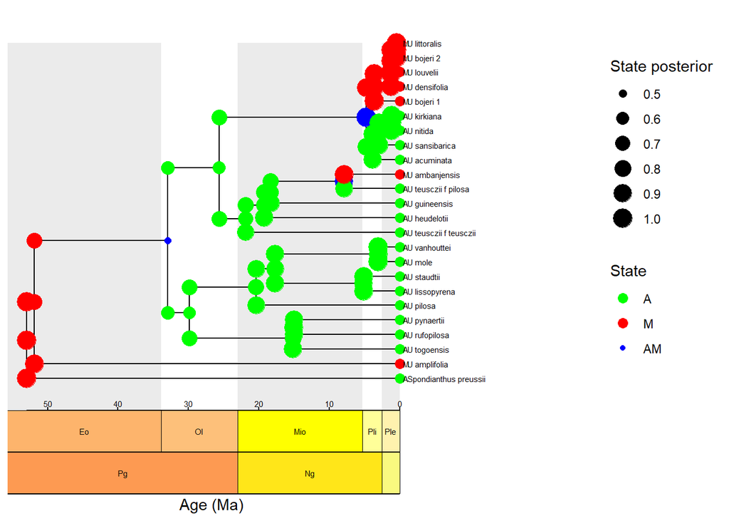

```r
# Randomly assign colors to all states
set.seed(1)
colors <-
  c(
    "#00FF00",
    "#FF0000",
    "#0000FF"
  )
names(colors) <- labs
# set.seed(1); colors = sample(colors)

# Plot the results with MAP estimates at nodes
map <- plotAncStatesMAP(
  t = anc_tree,
  # Include cladogenetic events
  cladogenetic = T,
  # Pass in the same color vector
  node_color = colors,
  # Print tip label states
  tip_labels_states = TRUE,
  # Offset those text labels slightly
  tip_labels_states_offset = .2,
  # adjust tip labels
  tip_labels_offset = 0.8,
  # increase tip states symbol size
  tip_states_size = 3,
  shoulder_states_size = 3,
  # opaque colors
  state_transparency = 1.0,
  timeline = TRUE
) +
  # adjust legend position and remove color guide
  theme(legend.position.inside = c(0.95, 0.36))
#pdf(plot_anc_map_fn, height = 9, width = 12)
print(map)
```

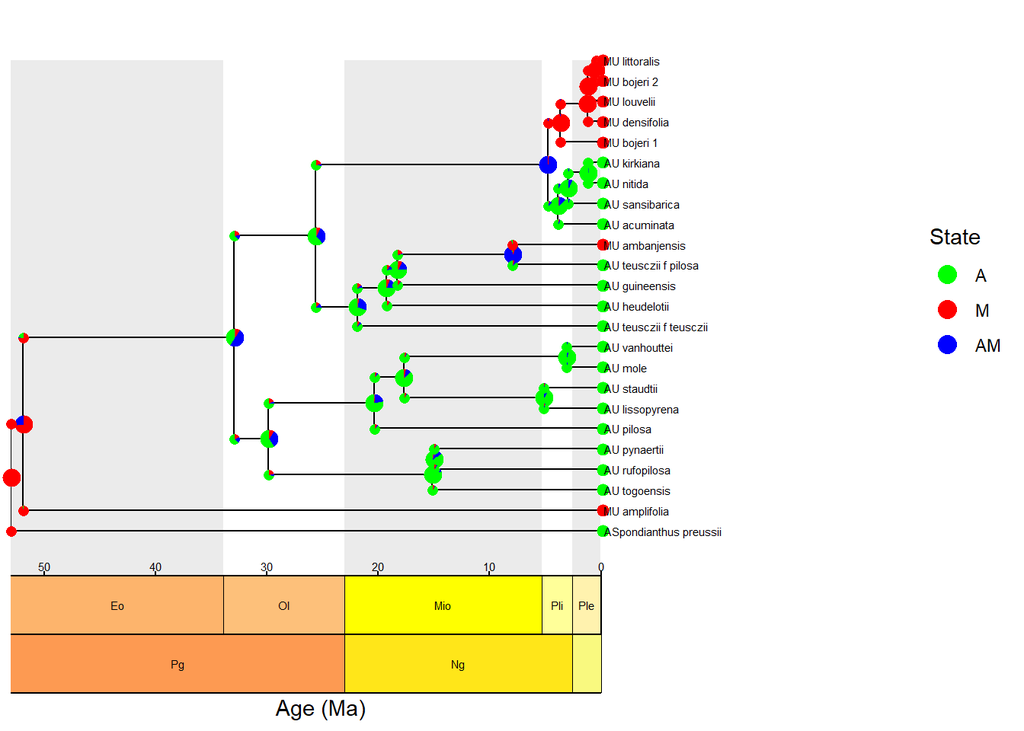

```r
#dev.off()

# Plot the results with pies at nodes
pie <- plotAncStatesPie(
  t = anc_tree,
  # Include cladogenetic events
  cladogenetic = TRUE,
  # Add text labels to the tip pie symbols
  tip_labels_states = TRUE,
  # Offset those text labels slightly
  tip_labels_states_offset = .4,
  # Pass in your named and ordered color vector
  pie_colors = colors,
  # Offset the tip labels to make room for tip pies
  tip_labels_offset = .7,
  # Move tip pies right slightly
  tip_pie_nudge_x = .1,
  # Change the size of node and tip pies
  tip_pie_size = 0.8,
  node_pie_size = 1.2,
  shoulder_pie_size = 0.7,
  # opaque colors
  state_transparency = 1.0,
  timeline = TRUE
) +
  # Move the legend
  theme(legend.position.inside = c(0.95, 0.7))
#pdf(plot_anc_pie_fn, height = 9, width = 12)
print(pie)
```

```r
#dev.off()
```